# Risk Factor Analysis

## Outcome Variable

**Outcome Variable:** pers_wast

## Predictor Variables

**Intervention Variable:** sex

**Adjustment Set:**

unadjusted

## Stratifying Variables

The analysis was stratified on these variable(s):

- agecat
- studyid
- country

## Data Summary

| agecat | studyid | country | sex | pers_wast | n_cell | n |
| --- | --- | --- | --- | --- | --- | --- |
| 0-24 months | ki0047075b-MAL-ED | BANGLADESH | Female | 0 | 116 | 248 |
| 0-24 months | ki0047075b-MAL-ED | BANGLADESH | Female | 1 | 9 | 248 |
| 0-24 months | ki0047075b-MAL-ED | BANGLADESH | Male | 0 | 119 | 248 |
| 0-24 months | ki0047075b-MAL-ED | BANGLADESH | Male | 1 | 4 | 248 |
| 0-24 months | ki0047075b-MAL-ED | BRAZIL | Female | 0 | 105 | 217 |
| 0-24 months | ki0047075b-MAL-ED | BRAZIL | Female | 1 | 2 | 217 |
| 0-24 months | ki0047075b-MAL-ED | BRAZIL | Male | 0 | 110 | 217 |
| 0-24 months | ki0047075b-MAL-ED | BRAZIL | Male | 1 | 0 | 217 |
| 0-24 months | ki0047075b-MAL-ED | INDIA | Female | 0 | 125 | 241 |
| 0-24 months | ki0047075b-MAL-ED | INDIA | Female | 1 | 8 | 241 |
| 0-24 months | ki0047075b-MAL-ED | INDIA | Male | 0 | 95 | 241 |
| 0-24 months | ki0047075b-MAL-ED | INDIA | Male | 1 | 13 | 241 |
| 0-24 months | ki0047075b-MAL-ED | NEPAL | Female | 0 | 110 | 238 |
| 0-24 months | ki0047075b-MAL-ED | NEPAL | Female | 1 | 0 | 238 |
| 0-24 months | ki0047075b-MAL-ED | NEPAL | Male | 0 | 124 | 238 |
| 0-24 months | ki0047075b-MAL-ED | NEPAL | Male | 1 | 4 | 238 |
| 0-24 months | ki0047075b-MAL-ED | PERU | Female | 0 | 131 | 284 |
| 0-24 months | ki0047075b-MAL-ED | PERU | Female | 1 | 0 | 284 |
| 0-24 months | ki0047075b-MAL-ED | PERU | Male | 0 | 152 | 284 |
| 0-24 months | ki0047075b-MAL-ED | PERU | Male | 1 | 1 | 284 |
| 0-24 months | ki0047075b-MAL-ED | SOUTH AFRICA | Female | 0 | 139 | 273 |
| 0-24 months | ki0047075b-MAL-ED | SOUTH AFRICA | Female | 1 | 1 | 273 |
| 0-24 months | ki0047075b-MAL-ED | SOUTH AFRICA | Male | 0 | 132 | 273 |
| 0-24 months | ki0047075b-MAL-ED | SOUTH AFRICA | Male | 1 | 1 | 273 |
| 0-24 months | ki0047075b-MAL-ED | TANZANIA, UNITED REPUBLIC OF | Female | 0 | 128 | 253 |
| 0-24 months | ki0047075b-MAL-ED | TANZANIA, UNITED REPUBLIC OF | Female | 1 | 0 | 253 |
| 0-24 months | ki0047075b-MAL-ED | TANZANIA, UNITED REPUBLIC OF | Male | 0 | 125 | 253 |
| 0-24 months | ki0047075b-MAL-ED | TANZANIA, UNITED REPUBLIC OF | Male | 1 | 0 | 253 |
| 0-24 months | ki1000108-CMC-V-BCS-2002 | INDIA | Female | 0 | 179 | 373 |
| 0-24 months | ki1000108-CMC-V-BCS-2002 | INDIA | Female | 1 | 8 | 373 |

[output cut: 342 more lines]

The following strata were considered:

- agecat: 0-24 months, studyid: ki0047075b-MAL-ED, country: BANGLADESH
- agecat: 0-24 months, studyid: ki0047075b-MAL-ED, country: BRAZIL
- agecat: 0-24 months, studyid: ki0047075b-MAL-ED, country: INDIA
- agecat: 0-24 months, studyid: ki0047075b-MAL-ED, country: NEPAL
- agecat: 0-24 months, studyid: ki0047075b-MAL-ED, country: PERU
- agecat: 0-24 months, studyid: ki0047075b-MAL-ED, country: SOUTH AFRICA
- agecat: 0-24 months, studyid: ki0047075b-MAL-ED, country: TANZANIA, UNITED REPUBLIC OF
- agecat: 0-24 months, studyid: ki1000108-CMC-V-BCS-2002, country: INDIA
- agecat: 0-24 months, studyid: ki1000108-IRC, country: INDIA
- agecat: 0-24 months, studyid: ki1000109-EE, country: PAKISTAN
- agecat: 0-24 months, studyid: ki1000109-ResPak, country: PAKISTAN
- agecat: 0-24 months, studyid: ki1000304b-SAS-CompFeed, country: INDIA
- agecat: 0-24 months, studyid: ki1000304b-SAS-FoodSuppl, country: INDIA
- agecat: 0-24 months, studyid: ki1017093-NIH-Birth, country: BANGLADESH
- agecat: 0-24 months, studyid: ki1017093b-PROVIDE, country: BANGLADESH
- agecat: 0-24 months, studyid: ki1017093c-NIH-Crypto, country: BANGLADESH
- agecat: 0-24 months, studyid: ki1066203-TanzaniaChild2, country: TANZANIA, UNITED REPUBLIC OF
- agecat: 0-24 months, studyid: ki1101329-Keneba, country: GAMBIA
- agecat: 0-24 months, studyid: ki1112895-Guatemala BSC, country: GUATEMALA
- agecat: 0-24 months, studyid: ki1112895-iLiNS-Zinc, country: BURKINA FASO
- agecat: 0-24 months, studyid: ki1113344-GMS-Nepal, country: NEPAL
- agecat: 0-24 months, studyid: ki1114097-CMIN, country: BANGLADESH
- agecat: 0-24 months, studyid: ki1114097-CMIN, country: BRAZIL
- agecat: 0-24 months, studyid: ki1114097-CMIN, country: GUINEA-BISSAU
- agecat: 0-24 months, studyid: ki1114097-CMIN, country: PERU
- agecat: 0-24 months, studyid: ki1114097-CONTENT, country: PERU
- agecat: 0-24 months, studyid: ki1119695-PROBIT, country: BELARUS
- agecat: 0-24 months, studyid: ki1126311-ZVITAMBO, country: ZIMBABWE
- agecat: 0-24 months, studyid: ki1135781-COHORTS, country: GUATEMALA
- agecat: 0-24 months, studyid: ki1135781-COHORTS, country: INDIA
- agecat: 0-24 months, studyid: ki1135781-COHORTS, country: PHILIPPINES
- agecat: 0-24 months, studyid: ki1148112-LCNI-5, country: MALAWI
- agecat: 0-24 months, studyid: kiGH5241-JiVitA-3, country: BANGLADESH
- agecat: 0-24 months, studyid: kiGH5241-JiVitA-4, country: BANGLADESH
- agecat: 0-6 months, studyid: ki0047075b-MAL-ED, country: BANGLADESH
- agecat: 0-6 months, studyid: ki0047075b-MAL-ED, country: BRAZIL
- agecat: 0-6 months, studyid: ki0047075b-MAL-ED, country: INDIA
- agecat: 0-6 months, studyid: ki0047075b-MAL-ED, country: NEPAL
- agecat: 0-6 months, studyid: ki0047075b-MAL-ED, country: PERU
- agecat: 0-6 months, studyid: ki0047075b-MAL-ED, country: SOUTH AFRICA
- agecat: 0-6 months, studyid: ki0047075b-MAL-ED, country: TANZANIA, UNITED REPUBLIC OF
- agecat: 0-6 months, studyid: ki1000108-CMC-V-BCS-2002, country: INDIA
- agecat: 0-6 months, studyid: ki1000108-IRC, country: INDIA
- agecat: 0-6 months, studyid: ki1000109-EE, country: PAKISTAN
- agecat: 0-6 months, studyid: ki1000109-ResPak, country: PAKISTAN
- agecat: 0-6 months, studyid: ki1017093-NIH-Birth, country: BANGLADESH
- agecat: 0-6 months, studyid: ki1017093b-PROVIDE, country: BANGLADESH
- agecat: 0-6 months, studyid: ki1017093c-NIH-Crypto, country: BANGLADESH
- agecat: 0-6 months, studyid: ki1066203-TanzaniaChild2, country: TANZANIA, UNITED REPUBLIC OF
- agecat: 0-6 months, studyid: ki1101329-Keneba, country: GAMBIA
- agecat: 0-6 months, studyid: ki1113344-GMS-Nepal, country: NEPAL
- agecat: 0-6 months, studyid: ki1114097-CMIN, country: BANGLADESH
- agecat: 0-6 months, studyid: ki1114097-CMIN, country: GUINEA-BISSAU
- agecat: 0-6 months, studyid: ki1114097-CMIN, country: PERU
- agecat: 0-6 months, studyid: ki1114097-CONTENT, country: PERU
- agecat: 0-6 months, studyid: ki1119695-PROBIT, country: BELARUS
- agecat: 0-6 months, studyid: ki1126311-ZVITAMBO, country: ZIMBABWE
- agecat: 0-6 months, studyid: ki1135781-COHORTS, country: PHILIPPINES
- agecat: 0-6 months, studyid: kiGH5241-JiVitA-3, country: BANGLADESH
- agecat: 6-24 months, studyid: ki0047075b-MAL-ED, country: BANGLADESH
- agecat: 6-24 months, studyid: ki0047075b-MAL-ED, country: BRAZIL
- agecat: 6-24 months, studyid: ki0047075b-MAL-ED, country: INDIA
- agecat: 6-24 months, studyid: ki0047075b-MAL-ED, country: NEPAL
- agecat: 6-24 months, studyid: ki0047075b-MAL-ED, country: PERU
- agecat: 6-24 months, studyid: ki0047075b-MAL-ED, country: SOUTH AFRICA
- agecat: 6-24 months, studyid: ki0047075b-MAL-ED, country: TANZANIA, UNITED REPUBLIC OF
- agecat: 6-24 months, studyid: ki1000108-CMC-V-BCS-2002, country: INDIA
- agecat: 6-24 months, studyid: ki1000108-IRC, country: INDIA
- agecat: 6-24 months, studyid: ki1000109-EE, country: PAKISTAN
- agecat: 6-24 months, studyid: ki1000109-ResPak, country: PAKISTAN
- agecat: 6-24 months, studyid: ki1000304b-SAS-CompFeed, country: INDIA
- agecat: 6-24 months, studyid: ki1000304b-SAS-FoodSuppl, country: INDIA
- agecat: 6-24 months, studyid: ki1017093-NIH-Birth, country: BANGLADESH
- agecat: 6-24 months, studyid: ki1017093b-PROVIDE, country: BANGLADESH
- agecat: 6-24 months, studyid: ki1017093c-NIH-Crypto, country: BANGLADESH
- agecat: 6-24 months, studyid: ki1066203-TanzaniaChild2, country: TANZANIA, UNITED REPUBLIC OF
- agecat: 6-24 months, studyid: ki1101329-Keneba, country: GAMBIA
- agecat: 6-24 months, studyid: ki1112895-Guatemala BSC, country: GUATEMALA
- agecat: 6-24 months, studyid: ki1112895-iLiNS-Zinc, country: BURKINA FASO
- agecat: 6-24 months, studyid: ki1113344-GMS-Nepal, country: NEPAL
- agecat: 6-24 months, studyid: ki1114097-CMIN, country: BANGLADESH
- agecat: 6-24 months, studyid: ki1114097-CMIN, country: BRAZIL
- agecat: 6-24 months, studyid: ki1114097-CMIN, country: GUINEA-BISSAU
- agecat: 6-24 months, studyid: ki1114097-CMIN, country: PERU
- agecat: 6-24 months, studyid: ki1114097-CONTENT, country: PERU
- agecat: 6-24 months, studyid: ki1119695-PROBIT, country: BELARUS
- agecat: 6-24 months, studyid: ki1126311-ZVITAMBO, country: ZIMBABWE
- agecat: 6-24 months, studyid: ki1135781-COHORTS, country: GUATEMALA
- agecat: 6-24 months, studyid: ki1135781-COHORTS, country: INDIA
- agecat: 6-24 months, studyid: ki1135781-COHORTS, country: PHILIPPINES
- agecat: 6-24 months, studyid: ki1148112-LCNI-5, country: MALAWI
- agecat: 6-24 months, studyid: kiGH5241-JiVitA-3, country: BANGLADESH
- agecat: 6-24 months, studyid: kiGH5241-JiVitA-4, country: BANGLADESH

### Dropped Strata

Some strata were dropped due to rare outcomes:

- agecat: 0-24 months, studyid: ki0047075b-MAL-ED, country: BANGLADESH
- agecat: 0-24 months, studyid: ki0047075b-MAL-ED, country: BRAZIL
- agecat: 0-24 months, studyid: ki0047075b-MAL-ED, country: NEPAL
- agecat: 0-24 months, studyid: ki0047075b-MAL-ED, country: PERU
- agecat: 0-24 months, studyid: ki0047075b-MAL-ED, country: SOUTH AFRICA
- agecat: 0-24 months, studyid: ki0047075b-MAL-ED, country: TANZANIA, UNITED REPUBLIC OF
- agecat: 0-24 months, studyid: ki1112895-Guatemala BSC, country: GUATEMALA
- agecat: 0-24 months, studyid: ki1114097-CMIN, country: BRAZIL
- agecat: 0-24 months, studyid: ki1114097-CMIN, country: PERU
- agecat: 0-24 months, studyid: ki1114097-CONTENT, country: PERU
- agecat: 0-24 months, studyid: ki1148112-LCNI-5, country: MALAWI
- agecat: 0-6 months, studyid: ki0047075b-MAL-ED, country: BANGLADESH
- agecat: 0-6 months, studyid: ki0047075b-MAL-ED, country: BRAZIL
- agecat: 0-6 months, studyid: ki0047075b-MAL-ED, country: NEPAL
- agecat: 0-6 months, studyid: ki0047075b-MAL-ED, country: PERU
- agecat: 0-6 months, studyid: ki0047075b-MAL-ED, country: SOUTH AFRICA
- agecat: 0-6 months, studyid: ki0047075b-MAL-ED, country: TANZANIA, UNITED REPUBLIC OF
- agecat: 0-6 months, studyid: ki1017093-NIH-Birth, country: BANGLADESH
- agecat: 0-6 months, studyid: ki1017093b-PROVIDE, country: BANGLADESH
- agecat: 0-6 months, studyid: ki1017093c-NIH-Crypto, country: BANGLADESH
- agecat: 0-6 months, studyid: ki1114097-CMIN, country: BANGLADESH
- agecat: 0-6 months, studyid: ki1114097-CMIN, country: GUINEA-BISSAU
- agecat: 0-6 months, studyid: ki1114097-CMIN, country: PERU
- agecat: 0-6 months, studyid: ki1114097-CONTENT, country: PERU
- agecat: 0-6 months, studyid: ki1126311-ZVITAMBO, country: ZIMBABWE
- agecat: 0-6 months, studyid: kiGH5241-JiVitA-3, country: BANGLADESH
- agecat: 6-24 months, studyid: ki0047075b-MAL-ED, country: BANGLADESH
- agecat: 6-24 months, studyid: ki0047075b-MAL-ED, country: BRAZIL
- agecat: 6-24 months, studyid: ki0047075b-MAL-ED, country: NEPAL
- agecat: 6-24 months, studyid: ki0047075b-MAL-ED, country: PERU
- agecat: 6-24 months, studyid: ki0047075b-MAL-ED, country: SOUTH AFRICA
- agecat: 6-24 months, studyid: ki0047075b-MAL-ED, country: TANZANIA, UNITED REPUBLIC OF
- agecat: 6-24 months, studyid: ki1112895-Guatemala BSC, country: GUATEMALA
- agecat: 6-24 months, studyid: ki1114097-CMIN, country: BRAZIL
- agecat: 6-24 months, studyid: ki1114097-CMIN, country: PERU
- agecat: 6-24 months, studyid: ki1114097-CONTENT, country: PERU
- agecat: 6-24 months, studyid: ki1148112-LCNI-5, country: MALAWI

## Methods Detail

We’re interested in the causal parameters $E[Y_a]$ for all values of $a \in \mathcal{A}$. These parameters represent the mean outcome if, possibly contrary to fact, we intervened to set all units to have $A=a$. Under the randomization and positivity assumptions, these are identified by the statistical parameters $\psi_a=E_W[E_{Y|A,W}(Y|A=a,W)]$. In addition, we’re interested in the mean of $Y$, $E[Y]$ under no intervention (the observed mean). We will estimate these parameters by using SuperLearner to fit the relevant likelihood factors – $E_{Y|A,W}(Y|A=a,W)$ and $p(A=a|W)$, and then updating our likelihood fit using a joint TMLE.

For unadjusted analyses ($W=\{\}$), initial likelihoods were estimated using Lrnr_glm to estimate the simple $E(Y|A)$ and Lrnr_mean to estimate $p(A)$. For adjusted analyses, a small library containing Lrnr_glmnet, Lrnr_xgboost, and Lrnr_mean was used.

Having estimated these parameters, we will then use the delta method to estimate relative risks and attributable risks relative to a prespecified baseline level of $A$.

# Results Detail

## Results Plots

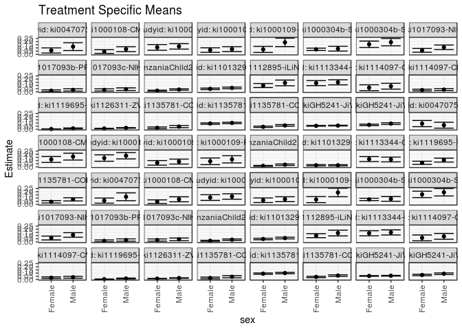

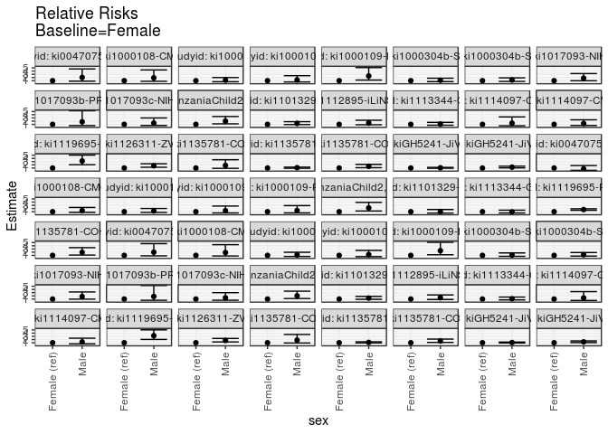

[figure not shown]

[figure not shown]

## Results Table

### Parameter: TSM

| agecat | studyid | country | intervention_level | baseline_level | estimate | ci_lower | ci_upper |
| --- | --- | --- | --- | --- | --- | --- | --- |
| 0-24 months | ki0047075b-MAL-ED | INDIA | Female | NA | 0.0601504 | 0.0196580 | 0.1006428 |
| 0-24 months | ki0047075b-MAL-ED | INDIA | Male | NA | 0.1203704 | 0.0588741 | 0.1818666 |
| 0-24 months | ki1000108-CMC-V-BCS-2002 | INDIA | Female | NA | 0.0427808 | 0.0137378 | 0.0718237 |
| 0-24 months | ki1000108-CMC-V-BCS-2002 | INDIA | Male | NA | 0.0806452 | 0.0414615 | 0.1198288 |
| 0-24 months | ki1000108-IRC | INDIA | Female | NA | 0.1081081 | 0.0633081 | 0.1529081 |
| 0-24 months | ki1000108-IRC | INDIA | Male | NA | 0.1244444 | 0.0812611 | 0.1676278 |
| 0-24 months | ki1000109-EE | PAKISTAN | Female | NA | 0.0659341 | 0.0298319 | 0.1020362 |
| 0-24 months | ki1000109-EE | PAKISTAN | Male | NA | 0.0820513 | 0.0434804 | 0.1206222 |
| 0-24 months | ki1000109-ResPak | PAKISTAN | Female | NA | 0.0762712 | 0.0282839 | 0.1242585 |
| 0-24 months | ki1000109-ResPak | PAKISTAN | Male | NA | 0.1879699 | 0.1214396 | 0.2545002 |
| 0-24 months | ki1000304b-SAS-CompFeed | INDIA | Female | NA | 0.0781759 | 0.0600535 | 0.0962983 |
| 0-24 months | ki1000304b-SAS-CompFeed | INDIA | Male | NA | 0.0877660 | 0.0500788 | 0.1254531 |
| 0-24 months | ki1000304b-SAS-FoodSuppl | INDIA | Female | NA | 0.1573604 | 0.1064433 | 0.2082775 |
| 0-24 months | ki1000304b-SAS-FoodSuppl | INDIA | Male | NA | 0.1910112 | 0.1331858 | 0.2488366 |
| 0-24 months | ki1017093-NIH-Birth | BANGLADESH | Female | NA | 0.0617284 | 0.0314412 | 0.0920156 |
| 0-24 months | ki1017093-NIH-Birth | BANGLADESH | Male | NA | 0.1099656 | 0.0739873 | 0.1459439 |
| 0-24 months | ki1017093b-PROVIDE | BANGLADESH | Female | NA | 0.0164474 | 0.0021387 | 0.0307560 |
| 0-24 months | ki1017093b-PROVIDE | BANGLADESH | Male | NA | 0.0297619 | 0.0115780 | 0.0479458 |
| 0-24 months | ki1017093c-NIH-Crypto | BANGLADESH | Female | NA | 0.0298103 | 0.0124465 | 0.0471741 |
| 0-24 months | ki1017093c-NIH-Crypto | BANGLADESH | Male | NA | 0.0415512 | 0.0209512 | 0.0621513 |
| 0-24 months | ki1066203-TanzaniaChild2 | TANZANIA, UNITED REPUBLIC OF | Female | NA | 0.0177239 | 0.0098235 | 0.0256242 |
| 0-24 months | ki1066203-TanzaniaChild2 | TANZANIA, UNITED REPUBLIC OF | Male | NA | 0.0356490 | 0.0246594 | 0.0466386 |
| 0-24 months | ki1101329-Keneba | GAMBIA | Female | NA | 0.0465313 | 0.0345210 | 0.0585416 |
| 0-24 months | ki1101329-Keneba | GAMBIA | Male | NA | 0.0611597 | 0.0479207 | 0.0743986 |
| 0-24 months | ki1112895-iLiNS-Zinc | BURKINA FASO | Female | NA | 0.0985222 | 0.0671712 | 0.1298731 |
| 0-24 months | ki1112895-iLiNS-Zinc | BURKINA FASO | Male | NA | 0.1400233 | 0.0951407 | 0.1849060 |
| 0-24 months | ki1113344-GMS-Nepal | NEPAL | Female | NA | 0.1368421 | 0.0969076 | 0.1767766 |
| 0-24 months | ki1113344-GMS-Nepal | NEPAL | Male | NA | 0.1498371 | 0.1098789 | 0.1897954 |
| 0-24 months | ki1114097-CMIN | BANGLADESH | Female | NA | 0.0642202 | 0.0181092 | 0.1103311 |
| 0-24 months | ki1114097-CMIN | BANGLADESH | Male | NA | 0.0878378 | 0.0421458 | 0.1335299 |

[output cut: 82 more lines]

### Parameter: E(Y)

| agecat | studyid | country | intervention_level | baseline_level | estimate | ci_lower | ci_upper |
| --- | --- | --- | --- | --- | --- | --- | --- |
| 0-24 months | ki0047075b-MAL-ED | INDIA | NA | NA | 0.0871369 | 0.0514552 | 0.1228187 |
| 0-24 months | ki1000108-CMC-V-BCS-2002 | INDIA | NA | NA | 0.0616622 | 0.0372186 | 0.0861058 |
| 0-24 months | ki1000108-IRC | INDIA | NA | NA | 0.1170732 | 0.0859146 | 0.1482317 |
| 0-24 months | ki1000109-EE | PAKISTAN | NA | NA | 0.0742706 | 0.0477670 | 0.1007741 |
| 0-24 months | ki1000109-ResPak | PAKISTAN | NA | NA | 0.1354582 | 0.0930379 | 0.1778785 |
| 0-24 months | ki1000304b-SAS-CompFeed | INDIA | NA | NA | 0.0834553 | 0.0601989 | 0.1067118 |
| 0-24 months | ki1000304b-SAS-FoodSuppl | INDIA | NA | NA | 0.1733333 | 0.1349698 | 0.2116969 |
| 0-24 months | ki1017093-NIH-Birth | BANGLADESH | NA | NA | 0.0880150 | 0.0639627 | 0.1120673 |
| 0-24 months | ki1017093b-PROVIDE | BANGLADESH | NA | NA | 0.0234375 | 0.0117074 | 0.0351676 |
| 0-24 months | ki1017093c-NIH-Crypto | BANGLADESH | NA | NA | 0.0356164 | 0.0221630 | 0.0490699 |
| 0-24 months | ki1066203-TanzaniaChild2 | TANZANIA, UNITED REPUBLIC OF | NA | NA | 0.0267775 | 0.0199775 | 0.0335775 |
| 0-24 months | ki1101329-Keneba | GAMBIA | NA | NA | 0.0540762 | 0.0451022 | 0.0630502 |
| 0-24 months | ki1112895-iLiNS-Zinc | BURKINA FASO | NA | NA | 0.1198322 | 0.0943748 | 0.1452897 |
| 0-24 months | ki1113344-GMS-Nepal | NEPAL | NA | NA | 0.1435811 | 0.1153098 | 0.1718524 |
| 0-24 months | ki1114097-CMIN | BANGLADESH | NA | NA | 0.0778210 | 0.0450051 | 0.1106369 |
| 0-24 months | ki1114097-CMIN | GUINEA-BISSAU | NA | NA | 0.0312229 | 0.0211797 | 0.0412661 |
| 0-24 months | ki1119695-PROBIT | BELARUS | NA | NA | 0.0095893 | 0.0052864 | 0.0138922 |
| 0-24 months | ki1126311-ZVITAMBO | ZIMBABWE | NA | NA | 0.0178935 | 0.0152039 | 0.0205831 |
| 0-24 months | ki1135781-COHORTS | GUATEMALA | NA | NA | 0.0340909 | 0.0231410 | 0.0450408 |
| 0-24 months | ki1135781-COHORTS | INDIA | NA | NA | 0.0964067 | 0.0887472 | 0.1040661 |
| 0-24 months | ki1135781-COHORTS | PHILIPPINES | NA | NA | 0.0512273 | 0.0430760 | 0.0593786 |
| 0-24 months | kiGH5241-JiVitA-3 | BANGLADESH | NA | NA | 0.0572741 | 0.0531873 | 0.0613609 |
| 0-24 months | kiGH5241-JiVitA-4 | BANGLADESH | NA | NA | 0.0806665 | 0.0720540 | 0.0892791 |
| 0-6 months | ki0047075b-MAL-ED | INDIA | NA | NA | 0.0791667 | 0.0449364 | 0.1133970 |
| 0-6 months | ki1000108-CMC-V-BCS-2002 | INDIA | NA | NA | 0.1396648 | 0.1037072 | 0.1756225 |
| 0-6 months | ki1000108-IRC | INDIA | NA | NA | 0.1592040 | 0.1233945 | 0.1950135 |
| 0-6 months | ki1000109-EE | PAKISTAN | NA | NA | 0.0737705 | 0.0469540 | 0.1005870 |
| 0-6 months | ki1000109-ResPak | PAKISTAN | NA | NA | 0.1041667 | 0.0654385 | 0.1428949 |
| 0-6 months | ki1066203-TanzaniaChild2 | TANZANIA, UNITED REPUBLIC OF | NA | NA | 0.0252305 | 0.0184583 | 0.0320026 |
| 0-6 months | ki1101329-Keneba | GAMBIA | NA | NA | 0.0250368 | 0.0182504 | 0.0318233 |
| 0-6 months | ki1113344-GMS-Nepal | NEPAL | NA | NA | 0.1199262 | 0.0925504 | 0.1473020 |
| 0-6 months | ki1119695-PROBIT | BELARUS | NA | NA | 0.0846069 | 0.0570929 | 0.1121208 |
| 0-6 months | ki1135781-COHORTS | PHILIPPINES | NA | NA | 0.0609613 | 0.0448957 | 0.0770269 |
| 6-24 months | ki0047075b-MAL-ED | INDIA | NA | NA | 0.0871369 | 0.0514552 | 0.1228187 |
| 6-24 months | ki1000108-CMC-V-BCS-2002 | INDIA | NA | NA | 0.0616622 | 0.0372186 | 0.0861058 |
| 6-24 months | ki1000108-IRC | INDIA | NA | NA | 0.1170732 | 0.0859146 | 0.1482317 |
| 6-24 months | ki1000109-EE | PAKISTAN | NA | NA | 0.0742706 | 0.0477670 | 0.1007741 |
| 6-24 months | ki1000109-ResPak | PAKISTAN | NA | NA | 0.1354582 | 0.0930379 | 0.1778785 |
| 6-24 months | ki1000304b-SAS-CompFeed | INDIA | NA | NA | 0.0834553 | 0.0601989 | 0.1067118 |
| 6-24 months | ki1000304b-SAS-FoodSuppl | INDIA | NA | NA | 0.1733333 | 0.1349698 | 0.2116969 |
| 6-24 months | ki1017093-NIH-Birth | BANGLADESH | NA | NA | 0.0880150 | 0.0639627 | 0.1120673 |
| 6-24 months | ki1017093b-PROVIDE | BANGLADESH | NA | NA | 0.0234375 | 0.0117074 | 0.0351676 |
| 6-24 months | ki1017093c-NIH-Crypto | BANGLADESH | NA | NA | 0.0356164 | 0.0221630 | 0.0490699 |
| 6-24 months | ki1066203-TanzaniaChild2 | TANZANIA, UNITED REPUBLIC OF | NA | NA | 0.0267775 | 0.0199775 | 0.0335775 |
| 6-24 months | ki1101329-Keneba | GAMBIA | NA | NA | 0.0540762 | 0.0451022 | 0.0630502 |
| 6-24 months | ki1112895-iLiNS-Zinc | BURKINA FASO | NA | NA | 0.1198322 | 0.0943748 | 0.1452897 |
| 6-24 months | ki1113344-GMS-Nepal | NEPAL | NA | NA | 0.1435811 | 0.1153098 | 0.1718524 |
| 6-24 months | ki1114097-CMIN | BANGLADESH | NA | NA | 0.0778210 | 0.0450051 | 0.1106369 |
| 6-24 months | ki1114097-CMIN | GUINEA-BISSAU | NA | NA | 0.0312229 | 0.0211797 | 0.0412661 |
| 6-24 months | ki1119695-PROBIT | BELARUS | NA | NA | 0.0095893 | 0.0052864 | 0.0138922 |
| 6-24 months | ki1126311-ZVITAMBO | ZIMBABWE | NA | NA | 0.0178935 | 0.0152039 | 0.0205831 |
| 6-24 months | ki1135781-COHORTS | GUATEMALA | NA | NA | 0.0340909 | 0.0231410 | 0.0450408 |
| 6-24 months | ki1135781-COHORTS | INDIA | NA | NA | 0.0964067 | 0.0887472 | 0.1040661 |
| 6-24 months | ki1135781-COHORTS | PHILIPPINES | NA | NA | 0.0512273 | 0.0430760 | 0.0593786 |
| 6-24 months | kiGH5241-JiVitA-3 | BANGLADESH | NA | NA | 0.0572741 | 0.0531873 | 0.0613609 |
| 6-24 months | kiGH5241-JiVitA-4 | BANGLADESH | NA | NA | 0.0806665 | 0.0720540 | 0.0892791 |

### Parameter: RR

| agecat | studyid | country | intervention_level | baseline_level | estimate | ci_lower | ci_upper |
| --- | --- | --- | --- | --- | --- | --- | --- |
| 0-24 months | ki0047075b-MAL-ED | INDIA | Female | Female | 1.0000000 | 1.0000000 | 1.000000 |
| 0-24 months | ki0047075b-MAL-ED | INDIA | Male | Female | 2.0011574 | 0.8595278 | 4.659106 |
| 0-24 months | ki1000108-CMC-V-BCS-2002 | INDIA | Female | Female | 1.0000000 | 1.0000000 | 1.000000 |
| 0-24 months | ki1000108-CMC-V-BCS-2002 | INDIA | Male | Female | 1.8850805 | 0.8180218 | 4.344051 |
| 0-24 months | ki1000108-IRC | INDIA | Female | Female | 1.0000000 | 1.0000000 | 1.000000 |
| 0-24 months | ki1000108-IRC | INDIA | Male | Female | 1.1511111 | 0.6704712 | 1.976307 |
| 0-24 months | ki1000109-EE | PAKISTAN | Female | Female | 1.0000000 | 1.0000000 | 1.000000 |
| 0-24 months | ki1000109-EE | PAKISTAN | Male | Female | 1.2444444 | 0.6047338 | 2.560865 |
| 0-24 months | ki1000109-ResPak | PAKISTAN | Female | Female | 1.0000000 | 1.0000000 | 1.000000 |
| 0-24 months | ki1000109-ResPak | PAKISTAN | Male | Female | 2.4644946 | 1.1973330 | 5.072719 |
| 0-24 months | ki1000304b-SAS-CompFeed | INDIA | Female | Female | 1.0000000 | 1.0000000 | 1.000000 |
| 0-24 months | ki1000304b-SAS-CompFeed | INDIA | Male | Female | 1.1226729 | 0.7109206 | 1.772904 |
| 0-24 months | ki1000304b-SAS-FoodSuppl | INDIA | Female | Female | 1.0000000 | 1.0000000 | 1.000000 |
| 0-24 months | ki1000304b-SAS-FoodSuppl | INDIA | Male | Female | 1.2138456 | 0.7793349 | 1.890614 |
| 0-24 months | ki1017093-NIH-Birth | BANGLADESH | Female | Female | 1.0000000 | 1.0000000 | 1.000000 |
| 0-24 months | ki1017093-NIH-Birth | BANGLADESH | Male | Female | 1.7814433 | 0.9877665 | 3.212845 |
| 0-24 months | ki1017093b-PROVIDE | BANGLADESH | Female | Female | 1.0000000 | 1.0000000 | 1.000000 |
| 0-24 months | ki1017093b-PROVIDE | BANGLADESH | Male | Female | 1.8095236 | 0.6249935 | 5.239056 |
| 0-24 months | ki1017093c-NIH-Crypto | BANGLADESH | Female | Female | 1.0000000 | 1.0000000 | 1.000000 |
| 0-24 months | ki1017093c-NIH-Crypto | BANGLADESH | Male | Female | 1.3938555 | 0.6486737 | 2.995085 |
| 0-24 months | ki1066203-TanzaniaChild2 | TANZANIA, UNITED REPUBLIC OF | Female | Female | 1.0000000 | 1.0000000 | 1.000000 |
| 0-24 months | ki1066203-TanzaniaChild2 | TANZANIA, UNITED REPUBLIC OF | Male | Female | 2.0113537 | 1.1698166 | 3.458272 |
| 0-24 months | ki1101329-Keneba | GAMBIA | Female | Female | 1.0000000 | 1.0000000 | 1.000000 |
| 0-24 months | ki1101329-Keneba | GAMBIA | Male | Female | 1.3143765 | 0.9384702 | 1.840853 |
| 0-24 months | ki1112895-iLiNS-Zinc | BURKINA FASO | Female | Female | 1.0000000 | 1.0000000 | 1.000000 |
| 0-24 months | ki1112895-iLiNS-Zinc | BURKINA FASO | Male | Female | 1.4212368 | 0.8801757 | 2.294899 |
| 0-24 months | ki1113344-GMS-Nepal | NEPAL | Female | Female | 1.0000000 | 1.0000000 | 1.000000 |
| 0-24 months | ki1113344-GMS-Nepal | NEPAL | Male | Female | 1.0949637 | 0.7374161 | 1.625874 |
| 0-24 months | ki1114097-CMIN | BANGLADESH | Female | Female | 1.0000000 | 1.0000000 | 1.000000 |
| 0-24 months | ki1114097-CMIN | BANGLADESH | Male | Female | 1.3677606 | 0.5635671 | 3.319514 |

[output cut: 82 more lines]

### Parameter: PAR

| agecat | studyid | country | intervention_level | baseline_level | estimate | ci_lower | ci_upper |
| --- | --- | --- | --- | --- | --- | --- | --- |
| 0-24 months | ki0047075b-MAL-ED | INDIA | Female | NA | 0.0269866 | -0.0062264 | 0.0601995 |
| 0-24 months | ki1000108-CMC-V-BCS-2002 | INDIA | Female | NA | 0.0188814 | -0.0055159 | 0.0432788 |
| 0-24 months | ki1000108-IRC | INDIA | Female | NA | 0.0089651 | -0.0251914 | 0.0431215 |
| 0-24 months | ki1000109-EE | PAKISTAN | Female | NA | 0.0083365 | -0.0190018 | 0.0356748 |
| 0-24 months | ki1000109-ResPak | PAKISTAN | Female | NA | 0.0591870 | 0.0151745 | 0.1031995 |
| 0-24 months | ki1000304b-SAS-CompFeed | INDIA | Female | NA | 0.0052794 | -0.0163323 | 0.0268912 |
| 0-24 months | ki1000304b-SAS-FoodSuppl | INDIA | Female | NA | 0.0159729 | -0.0206386 | 0.0525845 |
| 0-24 months | ki1017093-NIH-Birth | BANGLADESH | Female | NA | 0.0262866 | 0.0005773 | 0.0519959 |
| 0-24 months | ki1017093b-PROVIDE | BANGLADESH | Female | NA | 0.0069901 | -0.0051685 | 0.0191488 |
| 0-24 months | ki1017093c-NIH-Crypto | BANGLADESH | Female | NA | 0.0058061 | -0.0075240 | 0.0191363 |
| 0-24 months | ki1066203-TanzaniaChild2 | TANZANIA, UNITED REPUBLIC OF | Female | NA | 0.0090536 | 0.0022071 | 0.0159001 |
| 0-24 months | ki1101329-Keneba | GAMBIA | Female | NA | 0.0075449 | -0.0016791 | 0.0167689 |
| 0-24 months | ki1112895-iLiNS-Zinc | BURKINA FASO | Female | NA | 0.0213101 | -0.0078967 | 0.0505169 |
| 0-24 months | ki1113344-GMS-Nepal | NEPAL | Female | NA | 0.0067390 | -0.0225617 | 0.0360397 |
| 0-24 months | ki1114097-CMIN | BANGLADESH | Female | NA | 0.0136008 | -0.0238096 | 0.0510112 |
| 0-24 months | ki1114097-CMIN | GUINEA-BISSAU | Female | NA | 0.0036367 | -0.0063526 | 0.0136260 |
| 0-24 months | ki1119695-PROBIT | BELARUS | Female | NA | 0.0049327 | 0.0019579 | 0.0079075 |
| 0-24 months | ki1126311-ZVITAMBO | ZIMBABWE | Female | NA | 0.0047299 | 0.0020264 | 0.0074334 |
| 0-24 months | ki1135781-COHORTS | GUATEMALA | Female | NA | 0.0101865 | -0.0011581 | 0.0215311 |
| 0-24 months | ki1135781-COHORTS | INDIA | Female | NA | 0.0048727 | -0.0030174 | 0.0127628 |
| 0-24 months | ki1135781-COHORTS | PHILIPPINES | Female | NA | 0.0113477 | 0.0028348 | 0.0198606 |
| 0-24 months | kiGH5241-JiVitA-3 | BANGLADESH | Female | NA | 0.0017765 | -0.0022158 | 0.0057688 |
| 0-24 months | kiGH5241-JiVitA-4 | BANGLADESH | Female | NA | 0.0098868 | 0.0016370 | 0.0181367 |
| 0-6 months | ki0047075b-MAL-ED | INDIA | Female | NA | -0.0110589 | -0.0412879 | 0.0191701 |
| 0-6 months | ki1000108-CMC-V-BCS-2002 | INDIA | Female | NA | 0.0223464 | -0.0136113 | 0.0583040 |
| 0-6 months | ki1000108-IRC | INDIA | Female | NA | 0.0203151 | -0.0190506 | 0.0596807 |
| 0-6 months | ki1000109-EE | PAKISTAN | Female | NA | 0.0105521 | -0.0174408 | 0.0385450 |
| 0-6 months | ki1000109-ResPak | PAKISTAN | Female | NA | 0.0164474 | -0.0239911 | 0.0568858 |
| 0-6 months | ki1066203-TanzaniaChild2 | TANZANIA, UNITED REPUBLIC OF | Female | NA | 0.0094824 | 0.0026496 | 0.0163153 |
| 0-6 months | ki1101329-Keneba | GAMBIA | Female | NA | -0.0002668 | -0.0072618 | 0.0067281 |
| 0-6 months | ki1113344-GMS-Nepal | NEPAL | Female | NA | -0.0036259 | -0.0322735 | 0.0250216 |
| 0-6 months | ki1119695-PROBIT | BELARUS | Female | NA | 0.0205555 | 0.0157111 | 0.0254000 |
| 0-6 months | ki1135781-COHORTS | PHILIPPINES | Female | NA | 0.0198985 | 0.0035026 | 0.0362944 |
| 6-24 months | ki0047075b-MAL-ED | INDIA | Female | NA | 0.0269866 | -0.0062264 | 0.0601995 |
| 6-24 months | ki1000108-CMC-V-BCS-2002 | INDIA | Female | NA | 0.0188814 | -0.0055159 | 0.0432788 |
| 6-24 months | ki1000108-IRC | INDIA | Female | NA | 0.0089651 | -0.0251914 | 0.0431215 |
| 6-24 months | ki1000109-EE | PAKISTAN | Female | NA | 0.0083365 | -0.0190018 | 0.0356748 |
| 6-24 months | ki1000109-ResPak | PAKISTAN | Female | NA | 0.0591870 | 0.0151745 | 0.1031995 |
| 6-24 months | ki1000304b-SAS-CompFeed | INDIA | Female | NA | 0.0052794 | -0.0163323 | 0.0268912 |
| 6-24 months | ki1000304b-SAS-FoodSuppl | INDIA | Female | NA | 0.0159729 | -0.0206386 | 0.0525845 |
| 6-24 months | ki1017093-NIH-Birth | BANGLADESH | Female | NA | 0.0262866 | 0.0005773 | 0.0519959 |
| 6-24 months | ki1017093b-PROVIDE | BANGLADESH | Female | NA | 0.0069901 | -0.0051685 | 0.0191488 |
| 6-24 months | ki1017093c-NIH-Crypto | BANGLADESH | Female | NA | 0.0058061 | -0.0075240 | 0.0191363 |
| 6-24 months | ki1066203-TanzaniaChild2 | TANZANIA, UNITED REPUBLIC OF | Female | NA | 0.0090536 | 0.0022071 | 0.0159001 |
| 6-24 months | ki1101329-Keneba | GAMBIA | Female | NA | 0.0075449 | -0.0016791 | 0.0167689 |
| 6-24 months | ki1112895-iLiNS-Zinc | BURKINA FASO | Female | NA | 0.0213101 | -0.0078967 | 0.0505169 |
| 6-24 months | ki1113344-GMS-Nepal | NEPAL | Female | NA | 0.0067390 | -0.0225617 | 0.0360397 |
| 6-24 months | ki1114097-CMIN | BANGLADESH | Female | NA | 0.0136008 | -0.0238096 | 0.0510112 |
| 6-24 months | ki1114097-CMIN | GUINEA-BISSAU | Female | NA | 0.0036367 | -0.0063526 | 0.0136260 |
| 6-24 months | ki1119695-PROBIT | BELARUS | Female | NA | 0.0049327 | 0.0019579 | 0.0079075 |
| 6-24 months | ki1126311-ZVITAMBO | ZIMBABWE | Female | NA | 0.0047299 | 0.0020264 | 0.0074334 |
| 6-24 months | ki1135781-COHORTS | GUATEMALA | Female | NA | 0.0101865 | -0.0011581 | 0.0215311 |
| 6-24 months | ki1135781-COHORTS | INDIA | Female | NA | 0.0048727 | -0.0030174 | 0.0127628 |
| 6-24 months | ki1135781-COHORTS | PHILIPPINES | Female | NA | 0.0113477 | 0.0028348 | 0.0198606 |
| 6-24 months | kiGH5241-JiVitA-3 | BANGLADESH | Female | NA | 0.0017765 | -0.0022158 | 0.0057688 |
| 6-24 months | kiGH5241-JiVitA-4 | BANGLADESH | Female | NA | 0.0098868 | 0.0016370 | 0.0181367 |

### Parameter: PAF

| agecat | studyid | country | intervention_level | baseline_level | estimate | ci_lower | ci_upper |
| --- | --- | --- | --- | --- | --- | --- | --- |
| 0-24 months | ki0047075b-MAL-ED | INDIA | Female | NA | 0.3097028 | -0.1668719 | 0.5916345 |
| 0-24 months | ki1000108-CMC-V-BCS-2002 | INDIA | Female | NA | 0.3062078 | -0.1969410 | 0.5978519 |
| 0-24 months | ki1000108-IRC | INDIA | Female | NA | 0.0765766 | -0.2657912 | 0.3263416 |
| 0-24 months | ki1000109-EE | PAKISTAN | Female | NA | 0.1122449 | -0.3410611 | 0.4123242 |
| 0-24 months | ki1000109-ResPak | PAKISTAN | Female | NA | 0.4369392 | 0.0402860 | 0.6696542 |
| 0-24 months | ki1000304b-SAS-CompFeed | INDIA | Female | NA | 0.0632608 | -0.2198690 | 0.2806765 |
| 0-24 months | ki1000304b-SAS-FoodSuppl | INDIA | Female | NA | 0.0921515 | -0.1448916 | 0.2801162 |
| 0-24 months | ki1017093-NIH-Birth | BANGLADESH | Female | NA | 0.2986604 | -0.0485677 | 0.5309055 |
| 0-24 months | ki1017093b-PROVIDE | BANGLADESH | Female | NA | 0.2982456 | -0.4260208 | 0.6546619 |
| 0-24 months | ki1017093c-NIH-Crypto | BANGLADESH | Female | NA | 0.1630186 | -0.3014730 | 0.4617346 |
| 0-24 months | ki1066203-TanzaniaChild2 | TANZANIA, UNITED REPUBLIC OF | Female | NA | 0.3381047 | 0.0468217 | 0.5403742 |
| 0-24 months | ki1101329-Keneba | GAMBIA | Female | NA | 0.1395234 | -0.0473989 | 0.2930869 |
| 0-24 months | ki1112895-iLiNS-Zinc | BURKINA FASO | Female | NA | 0.1778325 | -0.0918924 | 0.3809286 |
| 0-24 months | ki1113344-GMS-Nepal | NEPAL | Female | NA | 0.0469350 | -0.1804539 | 0.2305223 |
| 0-24 months | ki1114097-CMIN | BANGLADESH | Female | NA | 0.1747706 | -0.4689051 | 0.5363870 |
| 0-24 months | ki1114097-CMIN | GUINEA-BISSAU | Female | NA | 0.1164751 | -0.2660807 | 0.3834388 |
| 0-24 months | ki1119695-PROBIT | BELARUS | Female | NA | 0.5143980 | 0.3192074 | 0.6536254 |
| 0-24 months | ki1126311-ZVITAMBO | ZIMBABWE | Female | NA | 0.2643375 | 0.1029446 | 0.3966936 |
| 0-24 months | ki1135781-COHORTS | GUATEMALA | Female | NA | 0.2988048 | -0.1056876 | 0.5553222 |
| 0-24 months | ki1135781-COHORTS | INDIA | Female | NA | 0.0505427 | -0.0348444 | 0.1288843 |
| 0-24 months | ki1135781-COHORTS | PHILIPPINES | Female | NA | 0.2215168 | 0.0405422 | 0.3683557 |
| 0-24 months | kiGH5241-JiVitA-3 | BANGLADESH | Female | NA | 0.0310183 | -0.0413987 | 0.0983995 |
| 0-24 months | kiGH5241-JiVitA-4 | BANGLADESH | Female | NA | 0.1225642 | 0.0157982 | 0.2177482 |
| 0-6 months | ki0047075b-MAL-ED | INDIA | Female | NA | -0.1396913 | -0.5878942 | 0.1820007 |
| 0-6 months | ki1000108-CMC-V-BCS-2002 | INDIA | Female | NA | 0.1600000 | -0.1380044 | 0.3799672 |
| 0-6 months | ki1000108-IRC | INDIA | Female | NA | 0.1276042 | -0.1567787 | 0.3420742 |
| 0-6 months | ki1000109-EE | PAKISTAN | Female | NA | 0.1430396 | -0.3295347 | 0.4476405 |
| 0-6 months | ki1000109-ResPak | PAKISTAN | Female | NA | 0.1578947 | -0.3296152 | 0.4666568 |
| 0-6 months | ki1066203-TanzaniaChild2 | TANZANIA, UNITED REPUBLIC OF | Female | NA | 0.3758328 | 0.0653954 | 0.5831556 |
| 0-6 months | ki1101329-Keneba | GAMBIA | Female | NA | -0.0106573 | -0.3324594 | 0.2334264 |
| 0-6 months | ki1113344-GMS-Nepal | NEPAL | Female | NA | -0.0302346 | -0.2989848 | 0.1829132 |
| 0-6 months | ki1119695-PROBIT | BELARUS | Female | NA | 0.2429532 | 0.1759314 | 0.3045242 |
| 0-6 months | ki1135781-COHORTS | PHILIPPINES | Female | NA | 0.3264121 | 0.0148310 | 0.5394489 |
| 6-24 months | ki0047075b-MAL-ED | INDIA | Female | NA | 0.3097028 | -0.1668719 | 0.5916345 |
| 6-24 months | ki1000108-CMC-V-BCS-2002 | INDIA | Female | NA | 0.3062078 | -0.1969410 | 0.5978519 |
| 6-24 months | ki1000108-IRC | INDIA | Female | NA | 0.0765766 | -0.2657912 | 0.3263416 |
| 6-24 months | ki1000109-EE | PAKISTAN | Female | NA | 0.1122449 | -0.3410611 | 0.4123242 |
| 6-24 months | ki1000109-ResPak | PAKISTAN | Female | NA | 0.4369392 | 0.0402860 | 0.6696542 |
| 6-24 months | ki1000304b-SAS-CompFeed | INDIA | Female | NA | 0.0632608 | -0.2198690 | 0.2806765 |
| 6-24 months | ki1000304b-SAS-FoodSuppl | INDIA | Female | NA | 0.0921515 | -0.1448916 | 0.2801162 |
| 6-24 months | ki1017093-NIH-Birth | BANGLADESH | Female | NA | 0.2986604 | -0.0485677 | 0.5309055 |
| 6-24 months | ki1017093b-PROVIDE | BANGLADESH | Female | NA | 0.2982456 | -0.4260208 | 0.6546619 |
| 6-24 months | ki1017093c-NIH-Crypto | BANGLADESH | Female | NA | 0.1630186 | -0.3014730 | 0.4617346 |
| 6-24 months | ki1066203-TanzaniaChild2 | TANZANIA, UNITED REPUBLIC OF | Female | NA | 0.3381047 | 0.0468217 | 0.5403742 |
| 6-24 months | ki1101329-Keneba | GAMBIA | Female | NA | 0.1395234 | -0.0473989 | 0.2930869 |
| 6-24 months | ki1112895-iLiNS-Zinc | BURKINA FASO | Female | NA | 0.1778325 | -0.0918924 | 0.3809286 |
| 6-24 months | ki1113344-GMS-Nepal | NEPAL | Female | NA | 0.0469350 | -0.1804539 | 0.2305223 |
| 6-24 months | ki1114097-CMIN | BANGLADESH | Female | NA | 0.1747706 | -0.4689051 | 0.5363870 |
| 6-24 months | ki1114097-CMIN | GUINEA-BISSAU | Female | NA | 0.1164751 | -0.2660807 | 0.3834388 |
| 6-24 months | ki1119695-PROBIT | BELARUS | Female | NA | 0.5143980 | 0.3192074 | 0.6536254 |
| 6-24 months | ki1126311-ZVITAMBO | ZIMBABWE | Female | NA | 0.2643375 | 0.1029446 | 0.3966936 |
| 6-24 months | ki1135781-COHORTS | GUATEMALA | Female | NA | 0.2988048 | -0.1056876 | 0.5553222 |
| 6-24 months | ki1135781-COHORTS | INDIA | Female | NA | 0.0505427 | -0.0348444 | 0.1288843 |
| 6-24 months | ki1135781-COHORTS | PHILIPPINES | Female | NA | 0.2215168 | 0.0405422 | 0.3683557 |
| 6-24 months | kiGH5241-JiVitA-3 | BANGLADESH | Female | NA | 0.0310183 | -0.0413987 | 0.0983995 |
| 6-24 months | kiGH5241-JiVitA-4 | BANGLADESH | Female | NA | 0.1225642 | 0.0157982 | 0.2177482 |